# SDC spatial focus areas

We use pre-computed raster maps from `02_sdcSpatial_DE.R`, see [GitHub repo](https://github.com/mamoeh/sdcSpatialExperiment_DE?organization=mamoeh&organization=mamoeh).

```r
library(sdcSpatial)
library(SpatialKWD)
library(sp)
library(raster)
library(viridisLite)
library(viridis)

load("sdcRasters_SHARE.RData")

pal <- rev(viridis(10))
```

## Making focus areas

Selecting four focus areas by: centroid (center point in ETRS89-LAEA) and size (measured in cell width).

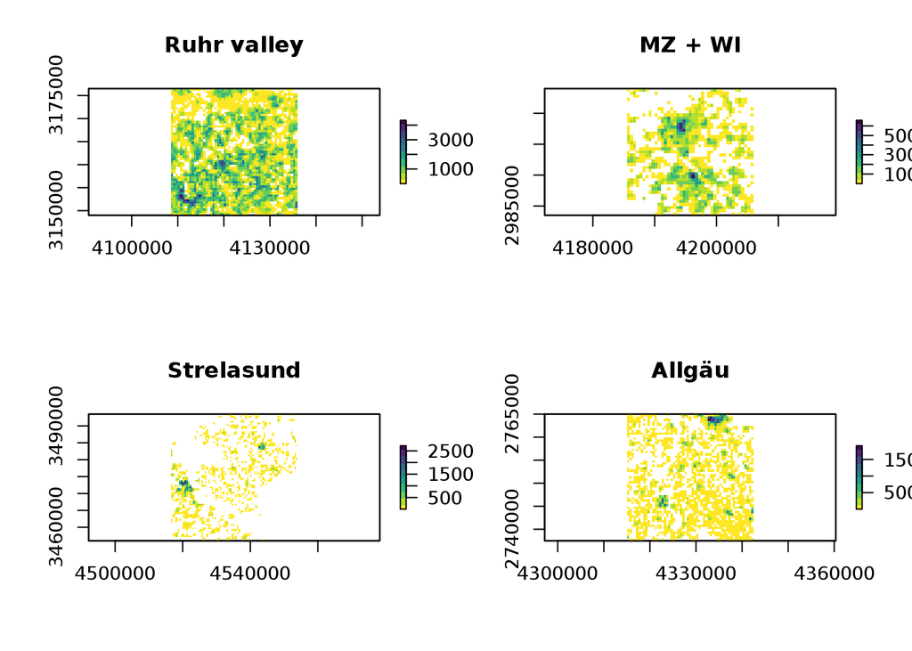

```r
fa1_ctrd <- c(4122250, 3162750)
fa2_ctrd <- c(4195750, 2993750)
fa3_ctrd <- c(4535250, 3474750)
fa4_ctrd <- c(4328750, 2751250)

cellsize <- 500

# focus area sizes
fa_wcells <- c(55, 41, 75, 55)

# find cell index of centroid in larger raster
fa1_cntr <- c(raster::colFromX(pop_ras$value, x = fa1_ctrd[1]),
              raster::rowFromY(pop_ras$value, y = fa1_ctrd[2]))
fa2_cntr <- c(raster::colFromX(pop_ras$value, x = fa2_ctrd[1]),
              raster::rowFromY(pop_ras$value, y = fa2_ctrd[2]))
fa3_cntr <- c(raster::colFromX(pop_ras$value, x = fa3_ctrd[1]),
              raster::rowFromY(pop_ras$value, y = fa3_ctrd[2]))
fa4_cntr <- c(raster::colFromX(pop_ras$value, x = fa4_ctrd[1]),
              raster::rowFromY(pop_ras$value, y = fa4_ctrd[2]))

# create extent objects for chosen positions & sizes
fa1_extt <- extent(pop_ras$value, fa1_cntr[2] - (fa_wcells[1] - 1)/2,
                                  fa1_cntr[2] + (fa_wcells[1] - 1)/2,
                                  fa1_cntr[1] - (fa_wcells[1] - 1)/2,
                                  fa1_cntr[1] + (fa_wcells[1] - 1)/2)

fa2_extt <- extent(pop_ras$value, fa2_cntr[2] - (fa_wcells[2] - 1)/2,
                                  fa2_cntr[2] + (fa_wcells[2] - 1)/2,
                                  fa2_cntr[1] - (fa_wcells[2] - 1)/2,
                                  fa2_cntr[1] + (fa_wcells[2] - 1)/2)

fa3_extt <- extent(pop_ras$value, fa3_cntr[2] - (fa_wcells[3] - 1)/2,
                                  fa3_cntr[2] + (fa_wcells[3] - 1)/2,
                                  fa3_cntr[1] - (fa_wcells[3] - 1)/2,
                                  fa3_cntr[1] + (fa_wcells[3] - 1)/2)

fa4_extt <- extent(pop_ras$value, fa4_cntr[2] - (fa_wcells[4] - 1)/2,
                                  fa4_cntr[2] + (fa_wcells[4] - 1)/2,
                                  fa4_cntr[1] - (fa_wcells[4] - 1)/2,
                                  fa4_cntr[1] + (fa_wcells[4] - 1)/2)

# crop overall raster to focus area for plotting & pop. counts
fa1 <- fa2 <- fa3 <- fa4 <- pop_ras
fa1$value <- crop(fa1$value, fa1_extt)
fa2$value <- crop(fa2$value, fa2_extt)
fa3$value <- crop(fa3$value, fa3_extt)
fa4$value <- crop(fa4$value, fa4_extt)

par(mfrow = c(2, 2))
  plot(fa1, "count", sensitive = FALSE, col = pal, main = "Ruhr valley")
  plot(fa2, "count", sensitive = FALSE, col = pal, main = "MZ + WI")
  plot(fa3, "count", sensitive = FALSE, col = pal, main = "Strelasund")
  plot(fa4, "count", sensitive = FALSE, col = pal, main = "Allgäu")
```

```r
par(mfrow = c(1, 1))

# calculate populations for subregions
p_fa <- c(sum(getValues(fa1$value$count), na.rm = TRUE),
          sum(getValues(fa2$value$count), na.rm = TRUE),
          sum(getValues(fa3$value$count), na.rm = TRUE),
          sum(getValues(fa4$value$count), na.rm = TRUE))

fa_sizes  <- cbind(fa_wcells,
                   fa_wcells^2,
                   fa_wcells^2 * cellsize^2 / 1e+6,
                   p_fa)
colnames(fa_sizes) <- c("width (ncells)", "size (ncells)", "size (km^2)", "pop.")
rownames(fa_sizes) <- c("fa1", "fa2", "fa3", "fa4")
fa_sizes
```

```
##     width (ncells) size (ncells) size (km^2)    pop.
## fa1             55          3025      756.25 1745062
## fa2             41          1681      420.25  558055
## fa3             75          5625     1406.25  107863
## fa4             55          3025      756.25  106283
```

## Risk and bin-by-bin measure for focus areas

We start by protecting focus areas, using the sdcSpatial algorithms. For this, wrapper functions are used:

```r
wrap_qt <- function(x, max_zoom = Inf, enlarge = TRUE) {

  if(enlarge) {
    pad <- min(2^max_zoom - 1, 10) # maximum padding is 10 (arbitrary)
    x$value <- extend(x$value, c(pad, pad))
    x <- sdcSpatial::protect_quadtree(x, max_zoom)
  } else {
    x <- sdcSpatial::protect_quadtree(x, max_zoom)
  }
  x
}

wrap_sm <- function(x, bw = res(x$value)[1], enlarge = TRUE) {

  if(enlarge) {
    pad <- 3 * (bw / res(x$value)[1])
    x$value <- extend(x$value, c(pad, pad))
    x <- sdcSpatial::protect_smooth(x, bw)
  } else {
    x <- sdcSpatial::protect_smooth(bw)
  }
  x
}
```

The idea behind these wrappers is to add some empty cells around the borders of the focus areas in order to capture distribution mass that ‘spills out’. This mass can then be taken into account later-on (esp. for KWD computation).

The necessary enlargement depends on the protection mechanism and can be inferred by looking into the functions sdcSpatial::protect_quadtree() and sdcSpatial::protect_smooth().

We call the (wrapped) protection algorithms separately for each focus area (4 methods times 4 areas = 16 outcomes).

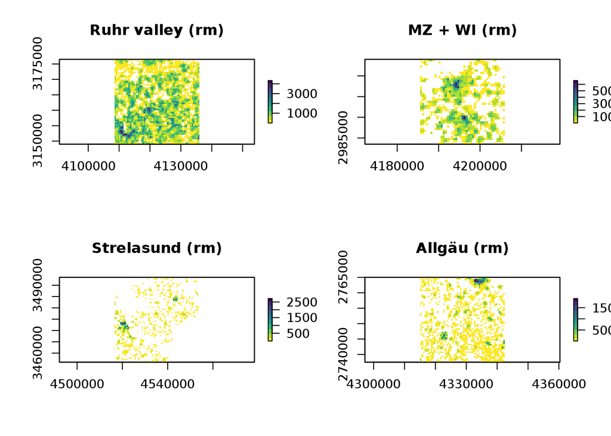

```r
par(mfrow = c(2, 2))

# removal
fa1_rm <- remove_sensitive(fa1)
fa2_rm <- remove_sensitive(fa2)
fa3_rm <- remove_sensitive(fa3)
fa4_rm <- remove_sensitive(fa4)

# quad tree I
fa1_qt1 <- wrap_qt(fa1, max_zoom = 2)
fa2_qt1 <- wrap_qt(fa2, max_zoom = 2)
fa3_qt1 <- wrap_qt(fa3, max_zoom = 2)
fa4_qt1 <- wrap_qt(fa4, max_zoom = 2)

# quad tree II
fa1_qt2 <- wrap_qt(fa1, max_zoom = 3)
fa2_qt2 <- wrap_qt(fa2, max_zoom = 3)
fa3_qt2 <- wrap_qt(fa3, max_zoom = 3)
fa4_qt2 <- wrap_qt(fa4, max_zoom = 3)

# smoothing
fa1_sm <- wrap_sm(fa1, bw = cellsize)
fa2_sm <- wrap_sm(fa2, bw = cellsize)
fa3_sm <- wrap_sm(fa3, bw = cellsize)
fa4_sm <- wrap_sm(fa4, bw = cellsize)


# show results

plot(fa1_rm, "count", sensitive = FALSE, col = pal, main = "Ruhr valley (rm)")
plot(fa2_rm, "count", sensitive = FALSE, col = pal, main = "MZ + WI (rm)")
plot(fa3_rm, "count", sensitive = FALSE, col = pal, main = "Strelasund (rm)")
plot(fa4_rm, "count", sensitive = FALSE, col = pal, main = "Allgäu (rm)")
```

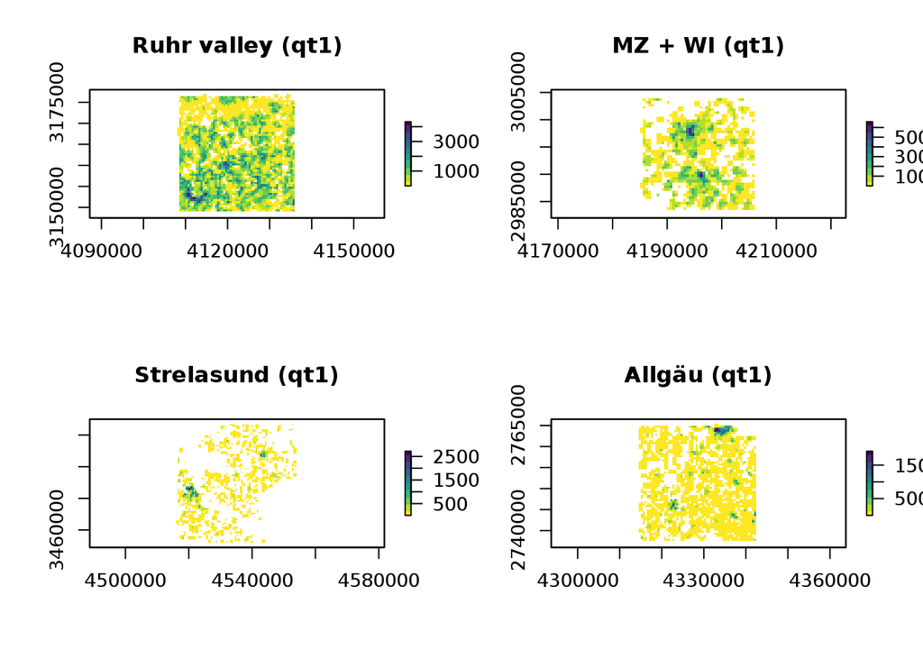

```r
plot(fa1_qt1, "count", sensitive = FALSE, col = pal, main = "Ruhr valley (qt1)")
plot(fa2_qt1, "count", sensitive = FALSE, col = pal, main = "MZ + WI (qt1)")
plot(fa3_qt1, "count", sensitive = FALSE, col = pal, main = "Strelasund (qt1)")
plot(fa4_qt1, "count", sensitive = FALSE, col = pal, main = "Allgäu (qt1)")
```

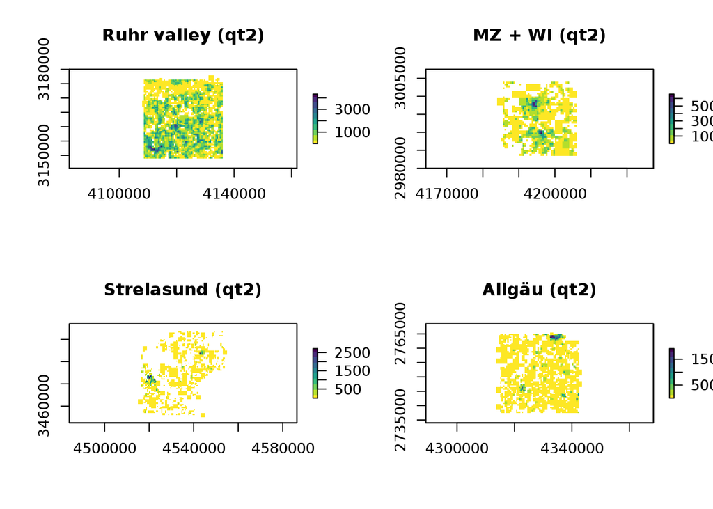

```r
plot(fa1_qt2, "count", sensitive = FALSE, col = pal, main = "Ruhr valley (qt2)")
plot(fa2_qt2, "count", sensitive = FALSE, col = pal, main = "MZ + WI (qt2)")
plot(fa3_qt2, "count", sensitive = FALSE, col = pal, main = "Strelasund (qt2)")
plot(fa4_qt2, "count", sensitive = FALSE, col = pal, main = "Allgäu (qt2)")
```

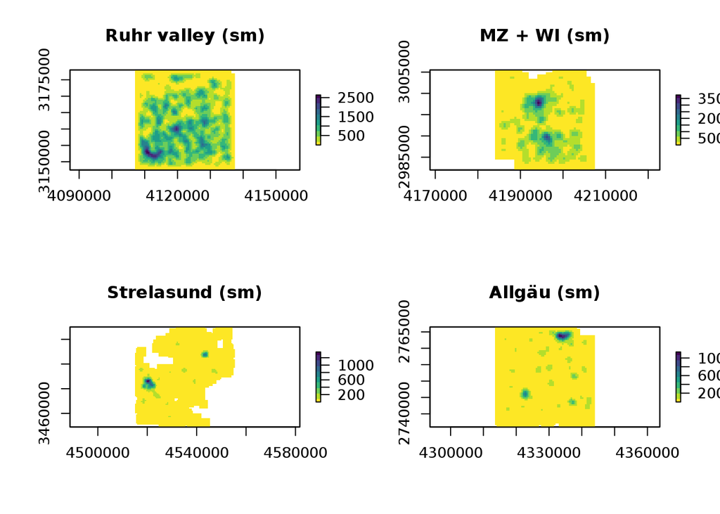

```r
plot(fa1_sm, "count", sensitive = FALSE, col = pal, main = "Ruhr valley (sm)")
plot(fa2_sm, "count", sensitive = FALSE, col = pal, main = "MZ + WI (sm)")
plot(fa3_sm, "count", sensitive = FALSE, col = pal, main = "Strelasund (sm)")
plot(fa4_sm, "count", sensitive = FALSE, col = pal, main = "Allgäu (sm)")
```

```r
par(mfrow = c(1, 1))
```

Note that for qt1, qt2 and sm the mass spills slightly beyond the original borders. We can show that with the exception of the removal method, all mass has been preserved:

```r
mass_rm  <- c(sum(getValues(fa1_rm$value$count),  na.rm = TRUE),
              sum(getValues(fa2_rm$value$count),  na.rm = TRUE),
              sum(getValues(fa3_rm$value$count),  na.rm = TRUE),
              sum(getValues(fa4_rm$value$count),  na.rm = TRUE))

mass_qt1 <- c(sum(getValues(fa1_qt1$value$count), na.rm = TRUE),
              sum(getValues(fa2_qt1$value$count), na.rm = TRUE),
              sum(getValues(fa3_qt1$value$count), na.rm = TRUE),
              sum(getValues(fa4_qt1$value$count), na.rm = TRUE))

mass_qt2 <- c(sum(getValues(fa1_qt2$value$count), na.rm = TRUE),
              sum(getValues(fa2_qt2$value$count), na.rm = TRUE),
              sum(getValues(fa3_qt2$value$count), na.rm = TRUE),
              sum(getValues(fa4_qt2$value$count), na.rm = TRUE))

mass_sm  <- c(sum(getValues(fa1_sm$value$count),  na.rm = TRUE),
              sum(getValues(fa2_sm$value$count),  na.rm = TRUE),
              sum(getValues(fa3_sm$value$count),  na.rm = TRUE),
              sum(getValues(fa4_sm$value$count),  na.rm = TRUE))

masses <- cbind(p_fa, mass_rm, mass_qt1, mass_qt2, mass_sm)
masses <- cbind(masses, round(masses[, 2:5] - p_fa))
colnames(masses) <- c("original", "removal", "quad tree I", "quad tree II", "smoothing",
                      "diff_removal", "diff_qt1", "diff_qt2", "diff_sm")
rownames(masses) <- c("fa1", "fa2", "fa3", "fa4")
masses
```

```
##     original removal quad tree I quad tree II smoothing diff_removal diff_qt1
## fa1  1745062 1744773     1745062      1745062   1745062         -289        0
## fa2   558055  557830      558055       558055    558055         -225        0
## fa3   107863  107175      107863       107863    107863         -688        0
## fa4   106283  105116      106283       106283    106283        -1167        0
##     diff_qt2 diff_sm
## fa1        0       0
## fa2        0       0
## fa3        0       0
## fa4        0       0
```

We can now calculate risk measures for the focus areas.

```r
# --- share of cells at risk ---
# initial
sens     <- c(sensitivity_score(fa1),     sensitivity_score(fa2),     sensitivity_score(fa3),     sensitivity_score(fa4))
# after SDC
sens_rm  <- c(sensitivity_score(fa1_rm),  sensitivity_score(fa2_rm),  sensitivity_score(fa3_rm),  sensitivity_score(fa4_rm))
sens_qt1 <- c(sensitivity_score(fa1_qt1), sensitivity_score(fa2_qt1), sensitivity_score(fa3_qt1), sensitivity_score(fa4_qt1))
sens_qt2 <- c(sensitivity_score(fa1_qt2), sensitivity_score(fa2_qt2), sensitivity_score(fa3_qt2), sensitivity_score(fa4_qt2))
sens_sm  <- c(sensitivity_score(fa1_sm),  sensitivity_score(fa2_sm),  sensitivity_score(fa3_sm),  sensitivity_score(fa4_sm))

risk_cell <- cbind(sens, sens_rm, sens_qt1, sens_qt2, sens_sm)
colnames(risk_cell) <- c("cell_initial", "cell_removal", "cell_quad tree I", "cell_quad tree II", "cell_smoothing")
rownames(risk_cell) <- c("fa1", "fa2", "fa3", "fa4")
round(risk_cell, 3)
```

```
##     cell_initial cell_removal cell_quad tree I cell_quad tree II cell_smoothing
## fa1        0.033            0            0.007                 0              0
## fa2        0.077            0            0.089                 0              0
## fa3        0.186            0            0.142                 0              0
## fa4        0.213            0            0.077                 0              0
```

```r
# --- share of pop. at risk ---
# initial
sensp <- c(sum(fa1$value$count[is_sensitive(fa1)]), sum(fa2$value$count[is_sensitive(fa2)]),
           sum(fa3$value$count[is_sensitive(fa3)]), sum(fa4$value$count[is_sensitive(fa4)]))
# after SDC
sensp_rm  <- c(sum(fa1_rm$value$count[is_sensitive(fa1_rm)]),   sum(fa2_rm$value$count[is_sensitive(fa2_rm)]),
               sum(fa3_rm$value$count[is_sensitive(fa3_rm)]),   sum(fa4_rm$value$count[is_sensitive(fa4_rm)]))
sensp_qt1 <- c(sum(fa1_qt1$value$count[is_sensitive(fa1_qt1)]), sum(fa2_qt1$value$count[is_sensitive(fa2_qt1)]),
               sum(fa3_qt1$value$count[is_sensitive(fa3_qt1)]), sum(fa4_qt1$value$count[is_sensitive(fa4_qt1)]))
sensp_qt2 <- c(sum(fa1_qt2$value$count[is_sensitive(fa1_qt2)]), sum(fa2_qt2$value$count[is_sensitive(fa2_qt2)]),
               sum(fa3_qt2$value$count[is_sensitive(fa3_qt2)]), sum(fa4_qt2$value$count[is_sensitive(fa4_qt2)]))
sensp_sm  <- c(sum(fa1_sm$value$count[is_sensitive(fa1_sm)]),   sum(fa2_sm$value$count[is_sensitive(fa2_sm)]),
               sum(fa3_sm$value$count[is_sensitive(fa3_sm)]),   sum(fa4_sm$value$count[is_sensitive(fa4_sm)]))
risk_pop <- cbind(sensp/p_fa, sensp_rm/p_fa, sensp_qt1/p_fa, sensp_qt2/p_fa, sensp_sm/p_fa)
colnames(risk_pop) <- c("pop_initial", "pop_removal", "pop_quad tree I", "pop_quad tree II", "pop_smoothing")
rownames(risk_pop) <- c("fa1", "fa2", "fa3", "fa4")
risk_pop
```

```
##      pop_initial pop_removal pop_quad tree I pop_quad tree II pop_smoothing
## fa1 0.0001656102           0    8.309160e-06                0             0
## fa2 0.0004031861           0    1.334994e-04                0             0
## fa3 0.0063784616           0    1.678055e-03                0             0
## fa4 0.0109801191           0    1.232558e-03                0             0
```

Next, we calculate the normalized Hellinger distances.

In accordance with the definition, mass mismatch does not bother the metric, so we consider only the original focus areas without enlargement around the borders. We therefore include a step where if the focus area was enlarged by a wrapper function, it gets cropped to its original size first.

```r
getHD <- function(x, orig, value = "count") {

  # resize protected raster if it was enlarged
  if(extent(x$value) > extent(orig$value)) {
    x$value <- crop(x$value, extent(orig$value))
  }

  # extract value raster of interest
  r_x <- x$value[[value]]
  r_o <- orig$value[[value]]

  # extract cell values
  v_x <- raster::getValues(r_x)
  v_o <- raster::getValues(r_o)

  # set NAs to 0
  v_x[is.na(v_x)] <- 0
  v_o[is.na(v_o)] <- 0

  # rescale
  v_x <- v_x / sum(v_x)
  v_o <- v_o / sum(v_o)

  HD <- sqrt(sum((sqrt(v_x) - sqrt(v_o))^2)) * (1/sqrt(2))
  HD
}

hd_rm  <- c(getHD(fa1_rm, fa1),  getHD(fa2_rm, fa2),  getHD(fa3_rm, fa3),  getHD(fa4_rm, fa4))
hd_qt1 <- c(getHD(fa1_qt1, fa1), getHD(fa2_qt1, fa2), getHD(fa3_qt1, fa3), getHD(fa4_qt1, fa4))
hd_qt2 <- c(getHD(fa1_qt2, fa1), getHD(fa2_qt2, fa2), getHD(fa3_qt2, fa3), getHD(fa4_qt2, fa4))
hd_sm  <- c(getHD(fa1_sm, fa1),  getHD(fa2_sm, fa2),  getHD(fa3_sm, fa3),  getHD(fa4_sm, fa4))

hd <- cbind(hd_rm, hd_qt1, hd_qt2, hd_sm)
colnames(hd) <- c("removal", "quad tree I", "quad tree II", "smoothing")
rownames(hd) <- c("fa1", "fa2", "fa3", "fa4")
round(hd, 3)
```

```
##     removal quad tree I quad tree II smoothing
## fa1   0.009       0.070        0.083     0.280
## fa2   0.014       0.114        0.213     0.366
## fa3   0.057       0.151        0.205     0.451
## fa4   0.074       0.167        0.226     0.416
```

## KWD for focus areas

KWD requires that both maps have the same mass and extent. By enlarging the focus areas slightly the mass was kept for all methods except removal (see above).

In order to account for the slightly larger extent, the ground truth is also slightly enlarged before the comparison. Since all the padding is made up of zero values, it does not distort the measure. This takes care of quadtree and smoothing.

```r
getKWD <- function(x, orig, value = "count", balance = "none", plot_map = FALSE, ...) {

  # resize original raster to balance mass for qt/sm
  if(extent(x$value) > extent(orig$value)) {
    orig$value <- extend(orig$value, extent(x$value))
  }

  if(balance == "frame") {
    x$value <- extend(x$value, c(1, 1), value = 0)
    orig$value <- extend(orig$value, c(1, 1), value = 0)
  }

  # extract value raster of interest
  r_x <- x$value[[value]]
  r_o <- orig$value[[value]]

  # extract cell values
  v_x <- raster::getValues(r_x)
  v_o <- raster::getValues(r_o)

  # set NAs to 0
  v_x[is.na(v_x)] <- 0
  v_o[is.na(v_o)] <- 0

  xy <- raster::xyFromCell(r_x, 1:ncell(r_x))

  # balance mass for removal
  if(balance %in% c("pop_ctrd", "frame")) {

    mdiff <- sum(v_o) - sum(v_x) # mass difference must be positive

    if(balance == "frame") {
      frameclls <- unique(c(raster::cellFromCol(r_x, c(1, ncol(r_x))),
                            raster::cellFromRow(r_x, c(1, nrow(r_x)))))
      r_x[frameclls] <- 1/(length(frameclls)) * mdiff
    }

    if(balance == "pop_ctrd") {

      # get population weighted centroid
      pop_ctrd <- c(stats::weighted.mean(xy[, 1], v_x),
                    stats::weighted.mean(xy[, 2], v_x))
      mcell <- cellFromXY(r_x, pop_ctrd)
      r_x[mcell] <- ifelse(is.na(r_x[mcell]), mdiff, r_x[mcell] + mdiff)
    }

    # extract new re-distributed mass
    v_x <- raster::getValues(r_x)
    v_x[is.na(v_x)] <- 0
  }

  if(plot_map) {
    plot(r_x, col = pal)
    if(balance == "frame") {
      fr <- extent(r_x, 2, ncol(r_x) - 1, 2, nrow(r_x) - 1)
    } else if(balance == "pop_ctrd") {
      fr <- c(xFromCell(r_x, mcell) - res(r_x)[1]/2,
              xFromCell(r_x, mcell) + res(r_x)[1]/2,
              yFromCell(r_x, mcell) - res(r_x)[2]/2,
              yFromCell(r_x, mcell) + res(r_x)[2]/2)
    }
    if(balance %in% c("frame", "pop_ctrd")) {
      rect(xleft = fr[1], xright = fr[2], ybottom = fr[3], ytop = fr[4],
           border = "red")
    }
  }

  KWD <- compareOneToOne(Coordinates = xy, Weights = cbind(v_x, v_o), ...)

  KWD$distance
}
```

For removal, we need to make assumptions on how to balance mass. Two versions of manually balancing are considered:

1. The missing mass gets added in a frame around the focus area. Therefore, missing mass in the visual center of the map gets punished more.
2. The missing mass gets added in a single cell at the population-weighted centroid of the map. The intuition behind this is that this point should be a kind of ‘best guess’ as to where it might be located.

```r
# Visualizing the two approaches:

par(mfrow = c(2, 2))

getKWD(fa1_rm, fa1, "count", balance = "frame", plot_map = TRUE)
```

```
## CompareOneToOne, Solution method: APPROX
## WARNING: the Xs input coordinates are not consecutives integers.
## WARNING: the Ys input coordinates are not consecutives integers.
## INFO: Recoding the input coordinates to consecutive integers.
## INFO: change <timelimit> to 14400.000000
## INFO: change <verbosity> to silent
## INFO: change <opt_tolerance> to 0.000001
```

```
## [1] 0.002546098
```

```r
getKWD(fa2_rm, fa2, "count", balance = "frame", plot_map = TRUE)
```

```
## CompareOneToOne, Solution method: APPROX
## WARNING: the Xs input coordinates are not consecutives integers.
## WARNING: the Ys input coordinates are not consecutives integers.
## INFO: Recoding the input coordinates to consecutive integers.
## INFO: change <timelimit> to 14400.000000
## INFO: change <verbosity> to silent
## INFO: change <opt_tolerance> to 0.000001
```

```
## [1] 0.00379919
```

```r
getKWD(fa3_rm, fa3, "count", balance = "frame", plot_map = TRUE)
```

```
## CompareOneToOne, Solution method: APPROX
## WARNING: the Xs input coordinates are not consecutives integers.
## WARNING: the Ys input coordinates are not consecutives integers.
## INFO: Recoding the input coordinates to consecutive integers.
## INFO: change <timelimit> to 14400.000000
## INFO: change <verbosity> to silent
## INFO: change <opt_tolerance> to 0.000001
```

```
## [1] 0.1285745
```

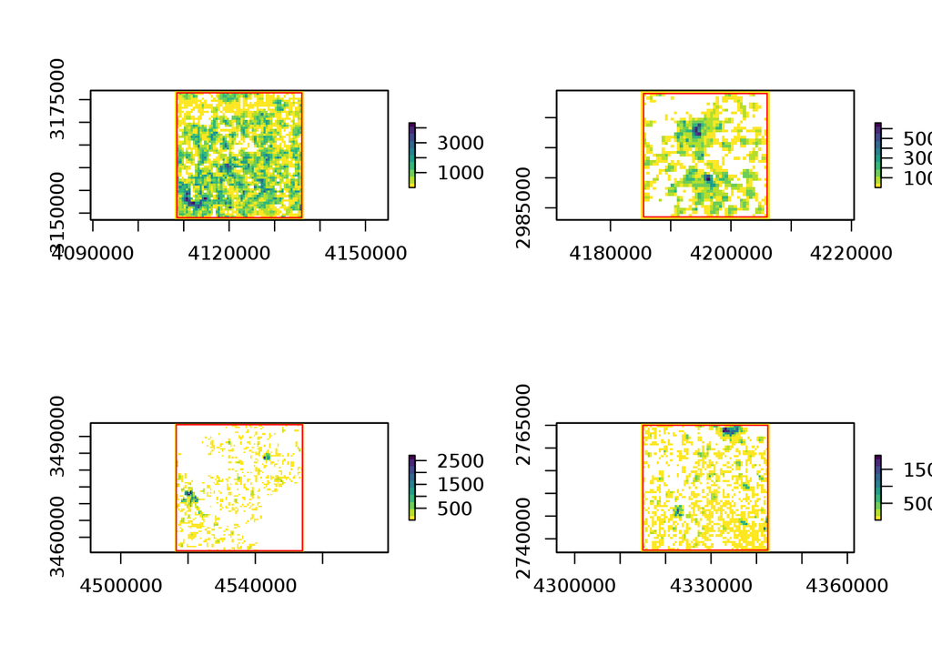

```
## CompareOneToOne, Solution method: APPROX
## WARNING: the Xs input coordinates are not consecutives integers.
## WARNING: the Ys input coordinates are not consecutives integers.
## INFO: Recoding the input coordinates to consecutive integers.
## INFO: change <timelimit> to 14400.000000
## INFO: change <verbosity> to silent
## INFO: change <opt_tolerance> to 0.000001
```

```
## [1] 0.1314477
```

```r
getKWD(fa4_rm, fa4, "count", balance = "frame", plot_map = TRUE)
```

```r
getKWD(fa1_rm, fa1, "count", balance = "pop_ctrd", plot_map = TRUE)
```

```
## CompareOneToOne, Solution method: APPROX
## WARNING: the Xs input coordinates are not consecutives integers.
## WARNING: the Ys input coordinates are not consecutives integers.
## INFO: Recoding the input coordinates to consecutive integers.
## INFO: change <timelimit> to 14400.000000
## INFO: change <verbosity> to silent
## INFO: change <opt_tolerance> to 0.000001
```

```
## [1] 0.004185462
```

```r
getKWD(fa2_rm, fa2, "count", balance = "pop_ctrd", plot_map = TRUE)
```

```
## CompareOneToOne, Solution method: APPROX
## WARNING: the Xs input coordinates are not consecutives integers.
## WARNING: the Ys input coordinates are not consecutives integers.
## INFO: Recoding the input coordinates to consecutive integers.
## INFO: change <timelimit> to 14400.000000
## INFO: change <verbosity> to silent
## INFO: change <opt_tolerance> to 0.000001
```

```
## [1] 0.006253455
```

```r
getKWD(fa3_rm, fa3, "count", balance = "pop_ctrd", plot_map = TRUE)
```

```
## CompareOneToOne, Solution method: APPROX
## WARNING: the Xs input coordinates are not consecutives integers.
## WARNING: the Ys input coordinates are not consecutives integers.
## INFO: Recoding the input coordinates to consecutive integers.
## INFO: change <timelimit> to 14400.000000
## INFO: change <verbosity> to silent
## INFO: change <opt_tolerance> to 0.000001
```

```
## [1] 0.1740762
```

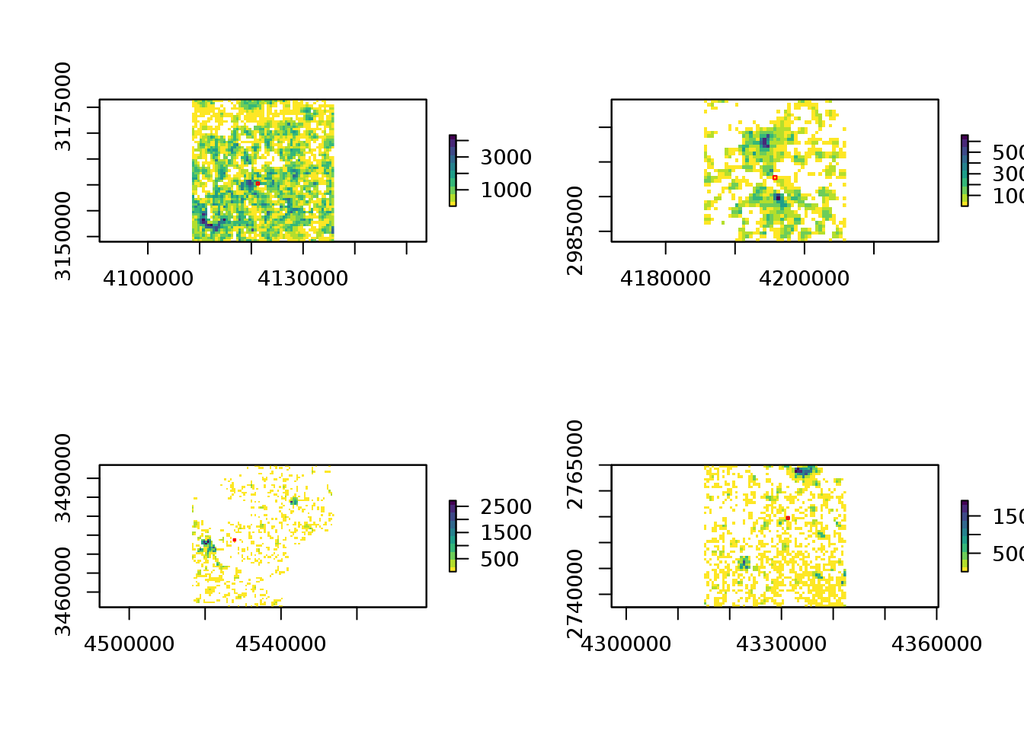

```
## CompareOneToOne, Solution method: APPROX
## WARNING: the Xs input coordinates are not consecutives integers.
## WARNING: the Ys input coordinates are not consecutives integers.
## INFO: Recoding the input coordinates to consecutive integers.
## INFO: change <timelimit> to 14400.000000
## INFO: change <verbosity> to silent
## INFO: change <opt_tolerance> to 0.000001
```

```
## [1] 0.2377131
```

```r
getKWD(fa4_rm, fa4, "count", balance = "pop_ctrd", plot_map = TRUE)
```

```r
par(mfrow = c(1, 1))
```

We compute now the KWD for all methods and focus areas. For removal, both ideas about mass balancing are compared.

```r
kwd_rm_f <- c(getKWD(fa1_rm, fa1, "count", balance = "frame"),
              getKWD(fa2_rm, fa2, "count", balance = "frame"),
              getKWD(fa3_rm, fa3, "count", balance = "frame"),
              getKWD(fa4_rm, fa4, "count", balance = "frame"))
```

[output not shown]

```r
kwd_rm_c <- c(getKWD(fa1_rm, fa1, "count", balance = "pop_ctrd"),
              getKWD(fa2_rm, fa2, "count", balance = "pop_ctrd"),
              getKWD(fa3_rm, fa3, "count", balance = "pop_ctrd"),
              getKWD(fa4_rm, fa4, "count", balance = "pop_ctrd"))
```

[output not shown]

```r
kwd_qt1 <- c(getKWD(fa1_qt1, fa1, "count"), getKWD(fa2_qt1, fa2, "count"),
             getKWD(fa3_qt1, fa3, "count"), getKWD(fa4_qt1, fa4, "count"))
```

[output not shown]

```r
kwd_qt2 <- c(getKWD(fa1_qt2, fa1, "count"), getKWD(fa2_qt2, fa2, "count"),
             getKWD(fa3_qt2, fa3, "count"), getKWD(fa4_qt2, fa4, "count"))
```

[output not shown]

```r
kwd_sm  <- c(getKWD(fa1_sm,  fa1, "count"), getKWD(fa2_sm,  fa2, "count"),
             getKWD(fa3_sm,  fa3, "count"), getKWD(fa4_sm,  fa4, "count"))
```

[output not shown]

```r
kwd <- cbind(kwd_rm_f, kwd_rm_c, kwd_qt1, kwd_qt2, kwd_sm)
colnames(kwd) <- c("removal (frame)", "removal (centroid)", "quad tree I", "quad tree II", "smoothing")
rownames(kwd) <- c("fa1", "fa2", "fa3", "fa4")
round(kwd, 3)
```

```
##     removal (frame) removal (centroid) quad tree I quad tree II smoothing
## fa1           0.003              0.004       0.012        0.018     0.381
## fa2           0.004              0.006       0.030        0.144     0.493
## fa3           0.129              0.174       0.053        0.119     0.626
## fa4           0.131              0.238       0.067        0.150     0.624
```

The results we get are now a lot more subtle.

Removal is not universally worse than other methods (according to KWD), but actually very good in the more densely populated areas, but beaten by quad tree in rural focus areas.

## Appendix:How to normalize KWD?

Some considerations on how to normalize KWD from the focusArea() function. Suppose we have a total count of 400. We move 10 units of mass by exactly one cell.

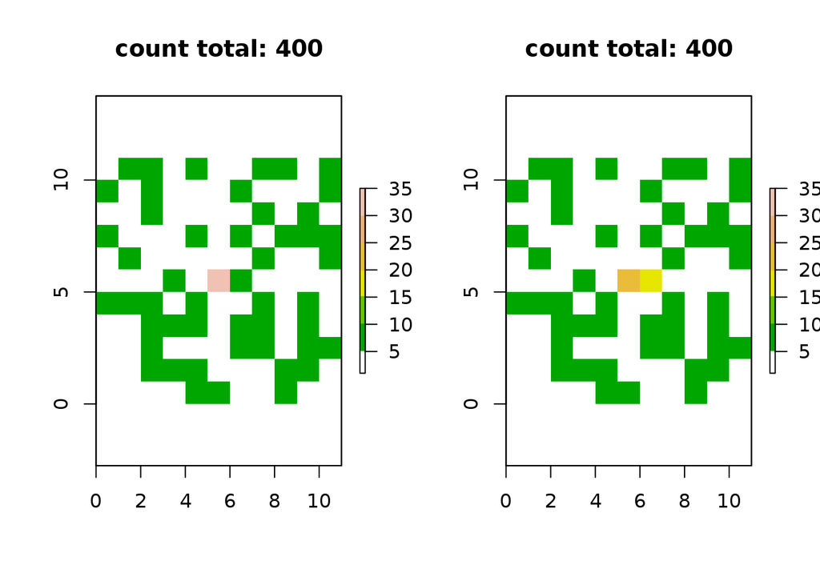

```r
wdth <- 11
m <- matrix(data = 1, nrow = wdth, ncol = wdth)

set.seed(100)
m[sample(1:(11^2), 50)] <- 6
m[6, 6] <- m[6, 6] + 29

r_exa <- raster(m, xmn = 0, xmx = wdth, ymn = 0, ymx = wdth)

r_exa2 <- r_exa
r_exa2[6, 6] <- r_exa2[6, 6] - 10
r_exa2[6, 7] <- r_exa2[6, 7] + 10

par(mfrow = c(1, 2))
plot(r_exa,  breaks = seq(5, 35, 5), col = terrain.colors(7),
     main = paste("count total:", sum(getValues(r_exa))))
plot(r_exa2, breaks = seq(5, 35, 5), col = terrain.colors(7),
     main = paste("count total:", sum(getValues(r_exa2))))
```

```r
par(mfrow = c(1, 1))
```

We know the KWD before normalization must be 10, afterwards 0.025.

```r
xy <- ceiling(raster::xyFromCell(r_exa, 1:ncell(r_exa)))

kwd_test <- compareOneToOne(Coordinates = xy,
                            Weights = cbind(getValues(r_exa), getValues(r_exa2)),
                            method = "exact")$distance
```

```
## CompareOneToOne, Solution method: EXACT
## INFO: Recoding the input coordinates to consecutive integers.
## INFO: change <timelimit> to 14400.000000
## INFO: change <verbosity> to silent
## INFO: change <opt_tolerance> to 0.000001
```

```r
kwd_fa_test <- focusArea(Coordinates = xy,
                         Weights = cbind(getValues(r_exa), getValues(r_exa2)),
                         x = 6, y = 6, radius = 3, area = "linf",
                         method = "exact")$distance
```

```
## FocusArea, Solution method: APPROX
## INFO: Recoding the input coordinates to consecutive integers.
## INFO: change <timelimit> to 14400.000000
## INFO: change <verbosity> to silent
## INFO: change <opt_tolerance> to 0.000001
```

```r
tst_results <- c(kwd_test, kwd_fa_test, kwd_fa_test / sum(getValues(r_exa2)))
names(tst_results) <- c("full map", "focus area", "focus area / sum(full map)")
tst_results
```

```
##                   full map                 focus area
##                      0.025                     10.000
## focus area / sum(full map)
##                      0.025
```

Suppose now we select our focus area from a smaller super area (with fewer total counts). In order to get to the same results we need to calibrate.

```r
r_exa_new  <- crop(r_exa, extent(r_exa,   2, wdth - 1, 2, wdth - 1))
r_exa2_new <- crop(r_exa2, extent(r_exa2, 2, wdth - 1, 2, wdth - 1))

fa_factor <- sum(getValues(r_exa)) / sum(getValues(r_exa_new))

xy <- ceiling(raster::xyFromCell(r_exa_new, 1:ncell(r_exa_new)))

kwd_test <- compareOneToOne(Coordinates = xy,
                            Weights = cbind(getValues(r_exa_new), getValues(r_exa2_new)),
                            method = "exact")$distance
```

```
## CompareOneToOne, Solution method: EXACT
## INFO: Recoding the input coordinates to consecutive integers.
## INFO: change <timelimit> to 14400.000000
## INFO: change <verbosity> to silent
## INFO: change <opt_tolerance> to 0.000001
```

```r
kwd_fa_test <- focusArea(Coordinates = xy,
                         Weights = cbind(getValues(r_exa_new), getValues(r_exa2_new)),
                         x = 5, y = 5, radius = 3, area = "linf",
                         method = "exact")$distance
```

```
## FocusArea, Solution method: APPROX
## INFO: Recoding the input coordinates to consecutive integers.
## INFO: change <timelimit> to 14400.000000
## INFO: change <verbosity> to silent
## INFO: change <opt_tolerance> to 0.000001
```

```r
tst_results <- c(kwd_test, kwd_test / fa_factor,
                 kwd_fa_test / sum(r_exa2_new[(5-3):(5+3), (5-3):(5+3)]),
                 (kwd_fa_test / sum(getValues(r_exa2_new)) / fa_factor))
names(tst_results) <- c("cropped area", "cropped area (calib.)", "focus area", "focus area (calib.)")
tst_results
```

```
##          cropped area cropped area (calib.)            focus area
##            0.03571429            0.02500000            0.05617978
##   focus area (calib.)
##            0.02500000
```